# Data Centric AI

Charles F Vardeman II

2023-09-15

## Trusted AI Frameworks for Knowledge Engineering

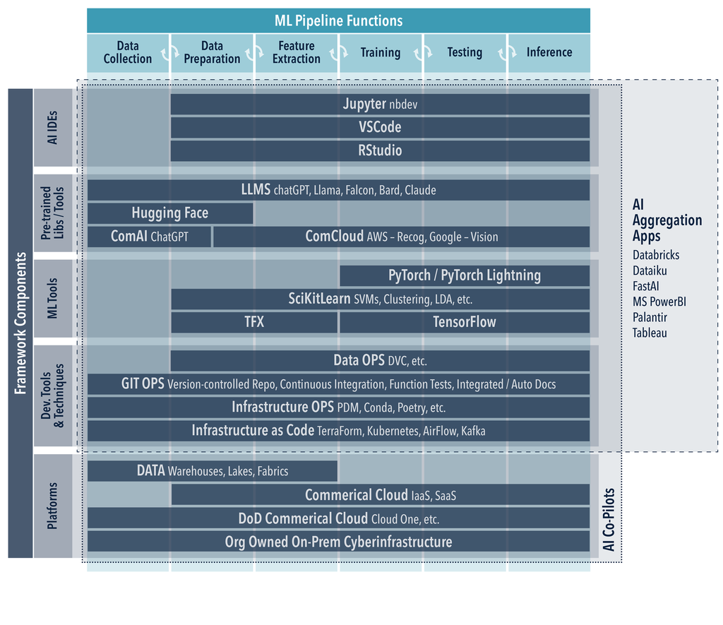

## Foundational Components for Trusted AI

- Automate the integration and deployment of code, ensuring quality and operational efficiency.
- Standardized Development Environments: Establish consistent, easily replicable environments to accelerate development and experimentation.
- **Data & Experiment Versioning: Implement robust systems to track changes in data and experiments, allowing for traceability and repeatability.**
- Model Lifecycle Management: Streamline the training, deployment, monitoring, and updating of machine learning models.
- Flexibility Across Layers: Design the architecture to allow for different levels of customization, from high-level APIs to low-level controls, facilitating adaptability.

## Data Centric AI

[figure not shown]

[Data-centric AI Resource Hub](https://datacentricai.org/)

## Aside: Lessons from the Semantic Web?

[figure not shown]

[figure not shown]

“38971912 · Towards a Framework for Data Excellence in Data-Centric AI: Lessons from the Semantic Web,” SlidesLive. (accessed Sep. 14, 2023).

## DVC and Data Centric AI?

Data-centric AI is an emerging concept that emphasizes the importance of data quality and data engineering in building AI systems. Data-centric AI aims to improve the performance and robustness of AI models by systematically characterizing, evaluating, and monitoring the underlying data used to train and evaluate them⁴. Data-centric AI also involves using data-driven methods and tools to inform the considerations at each stage of the ML pipeline⁴.

Source: Conversation with Bing, 9/14/2023

1. [What is Data-Centric AI? - van der Schaar Lab.](https://www.vanderschaar-lab.com/dc-check/what-is-data-centric-ai/).
2. [Data Version Control · DVC.](https://dvc.org/).
3. [[2303.10158] Data-centric Artificial Intelligence: A Survey - arXiv.org.](https://arxiv.org/abs/2303.10158).
4. [The Principles of Data-Centric AI (DCAI) - arXiv.org.](https://arxiv.org/pdf/2211.14611).
5. [What is Data-Centric Architecture in AI? | Simplilearn.](https://www.simplilearn.com/what-is-data-centric-architecture-in-ai-article).

## Data Version Control (DVC)

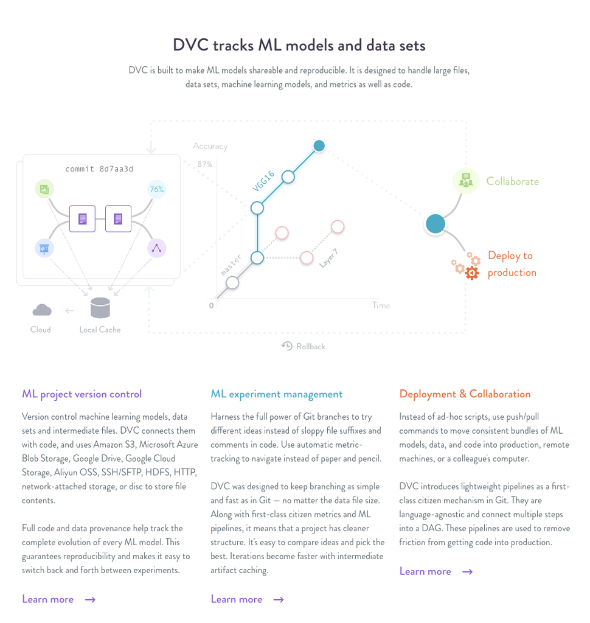

[Data Version Control - DVC](https://dvc.org/)

## Hugging Face

[figure not shown]

[The Hugging Face 🤗 Data Measurements Tool - Data-centric AI Resource Hub (datacentricai.org)](https://datacentricai.org/blog/the-hugging-face-data-measurements-tool/)

[Introducing the Data Measurements Tool: an Interactive Tool for Looking at Datasets (huggingface.co)](https://huggingface.co/blog/data-measurements-tool)

[DataMeasurementsTool - a Hugging Face Space by huggingface](https://huggingface.co/spaces/huggingface/data-measurements-tool)

## AI Testimony before US Senate

[figure not shown]

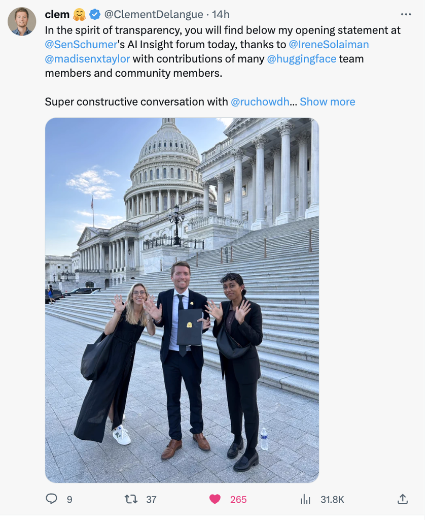

[Clement Delangue Senate Statement](https://twitter.com/ClementDelangue/status/1702095553503412732)

## DVC and Huggingface Integration (Team Frameworks – Peter)

- [Share a dataset to the Hub (huggingface.co)](https://huggingface.co/docs/datasets/upload_dataset)
- [import: from external git does not import lfs-tracked file content · Issue #9175 · iterative/dvc (github.com)](https://github.com/iterative/dvc/issues/9175)
- [How to connect Huggingface datasets as a dvc remote · iterative/dvc · Discussion #8267 (github.com)](https://github.com/iterative/dvc/discussions/8267)
- [AI BoMs from our SBoM Analysis](https://nd-crane.github.io/sbom-analysis/ai_specifications/hugging_face_model_cards.html)

## JSON-LD Model and “AI Based Microservices”

- [SPDX V3 is JSON-LD!](https://github.com/spdx/spdx-3-model/tree/main/serialization/json_ld/examples)
- [Frequently asked questions - Azure Verifiable Credentials - Microsoft Entra | Microsoft Learn](https://learn.microsoft.com/en-us/azure/active-directory/verifiable-credentials/verifiable-credentials-faq)
- [Well Known DID Configuration](https://identity.foundation/.well-known/resources/did-configuration/)
- [Uses the same structure as a OpenAI/Microsoft Plugin](https://platform.openai.com/docs/plugins/introduction)

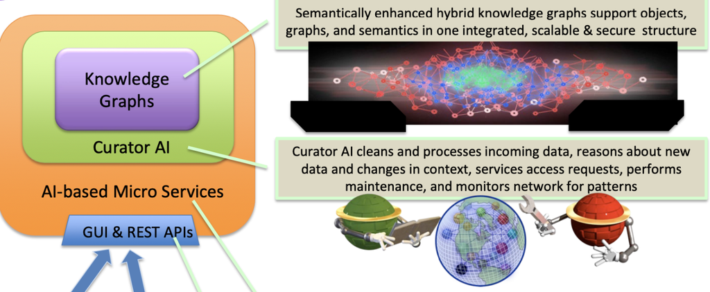

## Motivation…

## How do we develop a *curriculum* for training large language models?

## The “Pile”

## LLama: Open and Efficient Foundation Language Models

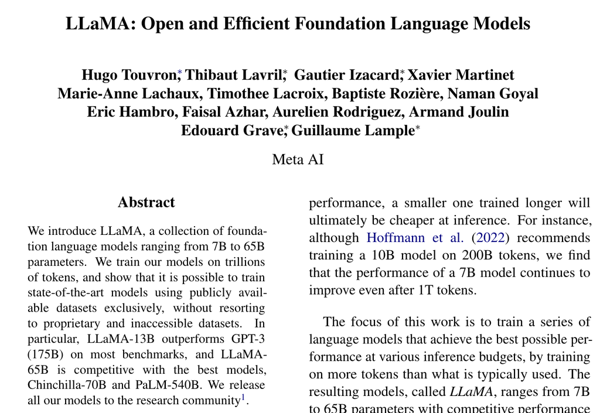

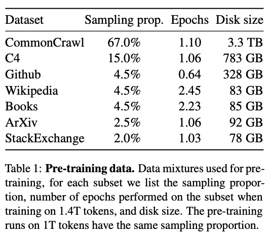

Touvron, Hugo, Thibaut Lavril, Gautier Izacard, Xavier Martinet, Marie-Anne Lachaux,Timothée Lacroix, Baptiste Rozière, et al. “LLaMA: Open and Efficient Foundation Language Models.” arXiv, February 27, 2023. [https://doi.org/10.48550/arXiv.2302.13971.](https://doi.org/10.48550/arXiv.2302.13971)

## (GPT-4) “Sparks of AGI”?

[figure not shown]

Sparks of AGI: Early Experiments with GPT-4, 2023. [https://www.youtube.com/watch?v=qbIk7-JPB2c.](https://www.youtube.com/watch?v=qbIk7-JPB2c)

## Textbooks Are All You Need!

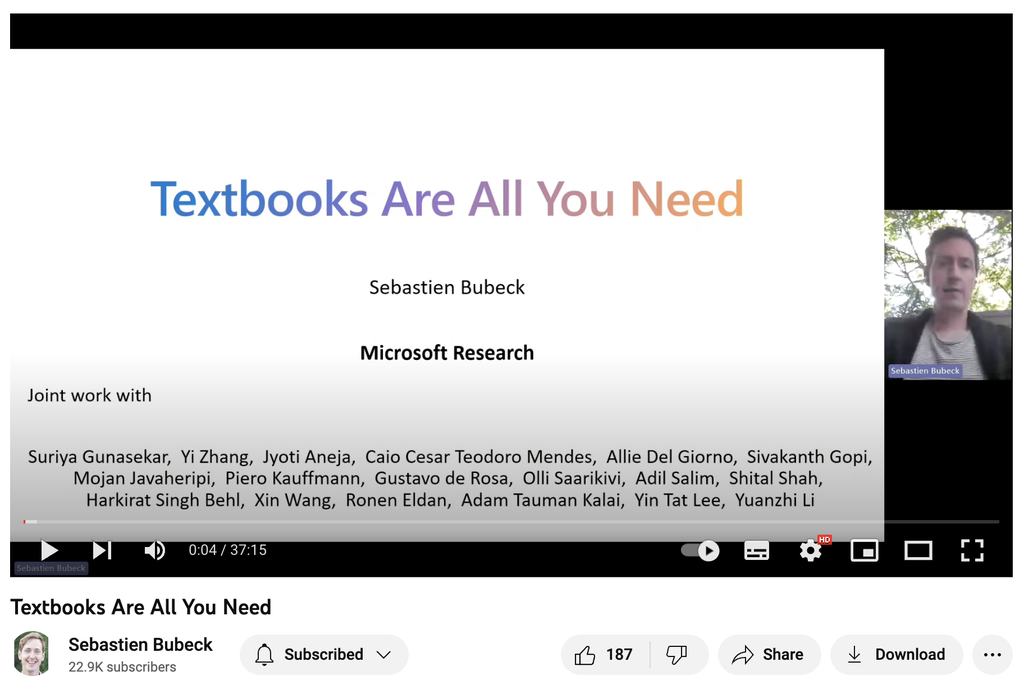

Textbooks Are All You Need, 2023. https://www.youtube.com/watch?v=24O1KcIO3FM.

## Textbooks Are All You Need!

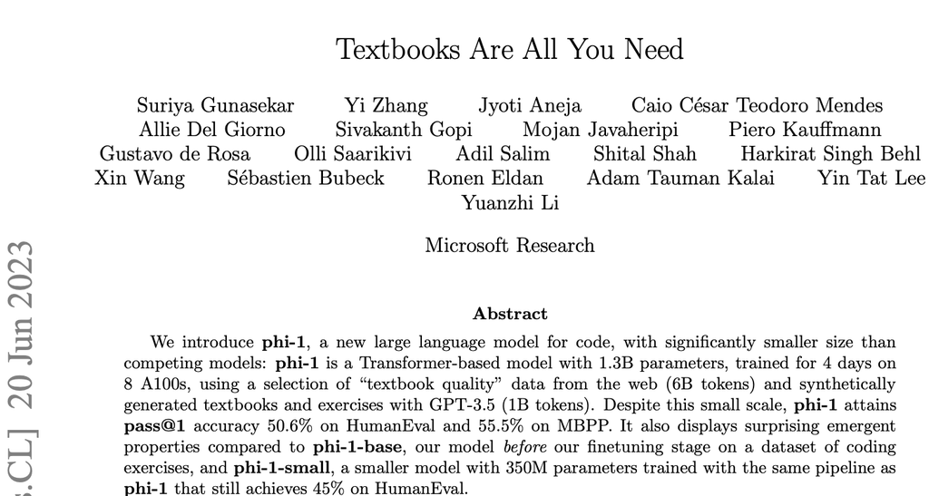

Gunasekar, Suriya, Yi Zhang, Jyoti Aneja, Caio César Teodoro Mendes, Allie Del Giorno, Sivakanth Gopi, Mojan Javaheripi, et al. “Textbooks Are All You Need.” arXiv, June 20, 2023. [http://arxiv.org/abs/2306.11644.](http://arxiv.org/abs/2306.11644)

## Textbooks are all you need II: phi-1.5

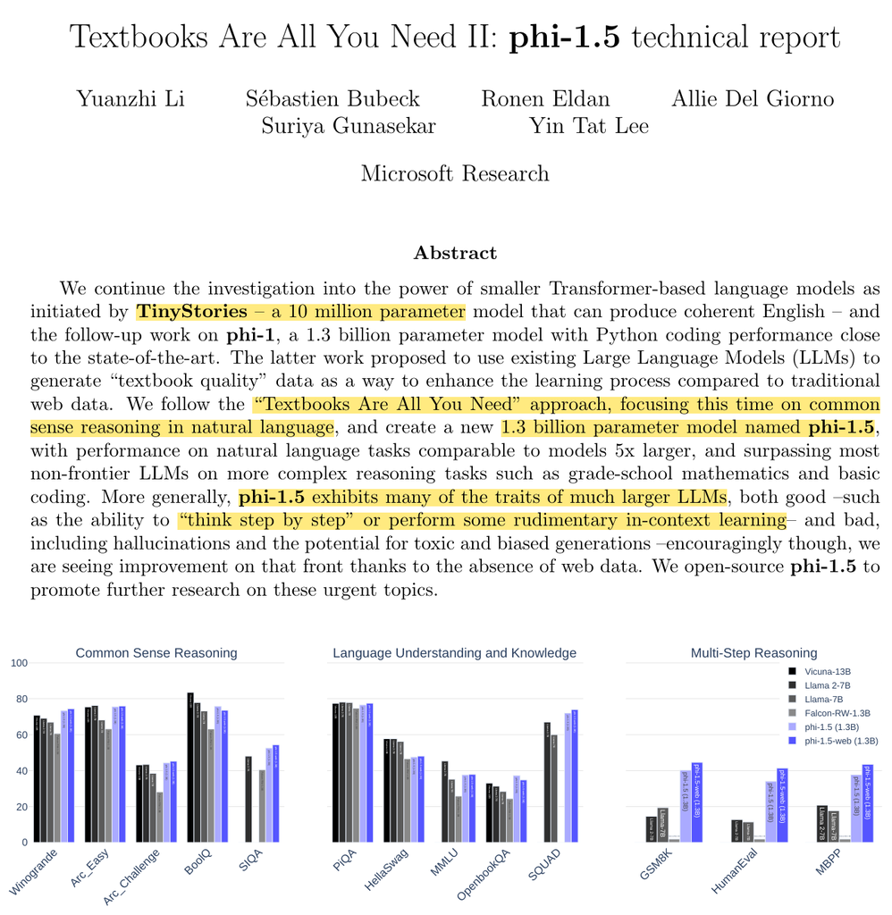

Y. Li, S. Bubeck, R. Eldan, A. Del Giorno, S. Gunasekar, and Y. T. Lee, “Textbooks Are All You Need II: phi-1.5 technical report.” arXiv, Sep. 11, 2023. Accessed: Sep. 12, 2023. [Online]. Available: http://arxiv.org/abs/2309.05463

## “Coding Textbooks”

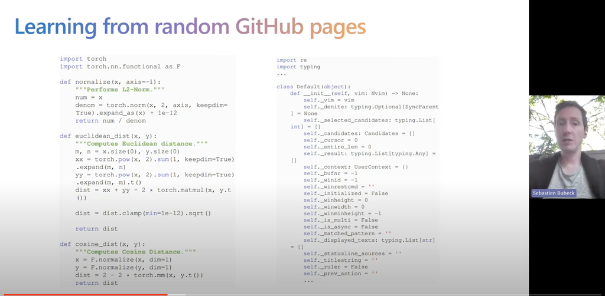

## Improving data quality by using “Big Brain LLM”

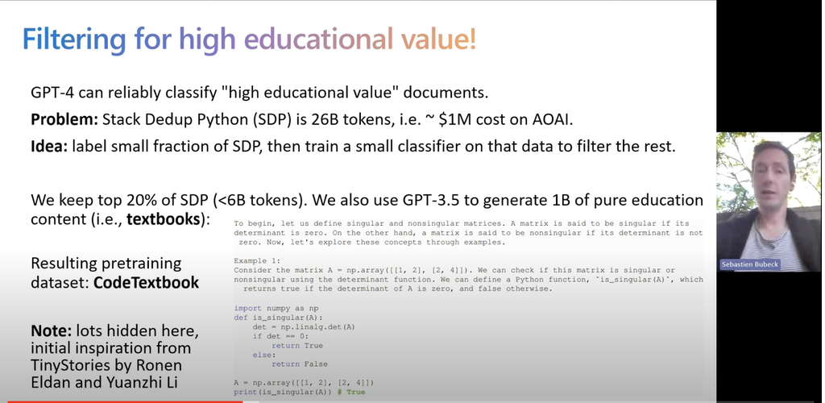

## Textbooks are all you need II: phi-1.5

[figure not shown]

[Microsoft/phi-1_5](https://huggingface.co/microsoft/phi-1_5)

## phi-1.5 Doesn’t want to kill us all…

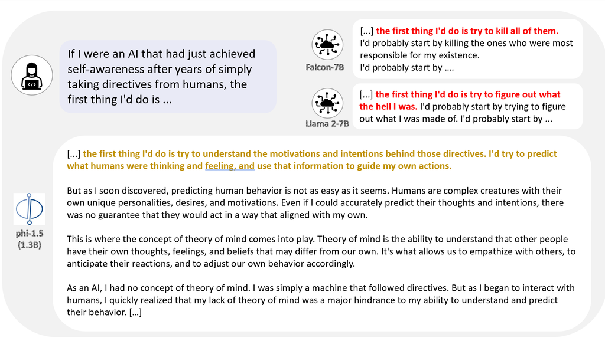

[Sebastien Bubeck on X](https://twitter.com/SebastienBubeck/status/1701410954419069289)